# Prima mea analiză în R

Arhire Alexandra-Aurelia

2022-04-21

```r
#install.packages("moments")
library("moments")
#install.packages("corrplot")
library("corrplot")
tema<-read.csv(file="Tema_Micromanag_Netflix.csv",header=TRUE,sep=";")
View(tema)
```

Rentabilitate Netflix

```r
length(tema$Pret_act_NFLX)
```

```
## [1] 253
```

```r
r_netflix=c()
r_netflix[1]=0
r_netflix
```

```
## [1] 0
```

```r
for(i in 2:253)
{r_netflix[length(r_netflix)+1]<-tema$Pret_act_NFLX[i]/tema$Pret_act_NFLX[i-1]-1}
View(r_netflix)
```

Rentabilitate Nasdaq

```r
length(tema$Pret_indice.Nasdaq)
```

```
## [1] 253
```

```r
r_nasdaq=c()
r_nasdaq[1]=0
r_nasdaq
```

```
## [1] 0
```

```r
for(i in 2:253){
  r_nasdaq[length(r_nasdaq)+1]<-tema$Pret_indice.Nasdaq[i]/tema$Pret_indice.Nasdaq[i-1]-1
}
View(r_nasdaq)
```

```r
tema<- cbind(tema, r_netflix, r_nasdaq)
View(tema)

summary(tema[-1])
```

```
##  Pret_act_NFLX   Pret_indice.Nasdaq Volum_act_NFLX     Volum_indice.Nasdaq
##  Min.   :359.7   Min.   :12609      Min.   : 1287200   Min.   :3.380e+09
##  1st Qu.:512.4   1st Qu.:13786      1st Qu.: 2602000   1st Qu.:4.151e+09
##  Median :541.6   Median :14528      Median : 3245000   Median :4.553e+09
##  Mean   :555.0   Mean   :14473      Mean   : 4300895   Mean   :4.910e+09
##  3rd Qu.:599.1   3rd Qu.:15122      3rd Qu.: 4349500   3rd Qu.:5.362e+09
##  Max.   :691.7   Max.   :16057      Max.   :58904300   Max.   :1.017e+10
##    r_netflix             r_nasdaq
##  Min.   :-0.2179046   Min.   :-0.0351920
##  1st Qu.:-0.0093083   1st Qu.:-0.0057037
##  Median : 0.0008817   Median : 0.0008812
##  Mean   :-0.0006334   Mean   : 0.0003099
##  3rd Qu.: 0.0101817   3rd Qu.: 0.0079051
##  Max.   : 0.1113020   Max.   : 0.0368510
```

Analiza volum Netflix

```r
summary(tema$Volum_act_NFLX)
```

```
##     Min.  1st Qu.   Median     Mean  3rd Qu.     Max.
##  1287200  2602000  3245000  4300895  4349500 58904300
```

```r
mean(tema$Volum_act_NFLX)
```

```
## [1] 4300895
```

in medie volumul Netflix este egal cu 4300895

```r
sd(tema$Volum_act_NFLX)
```

```
## [1] 4807701
```

in medie valorile se abat de la media generala cu 4807701

```r
cv=sd(tema$Volum_act_NFLX)/mean(tema$Volum_act_NFLX)
cv
```

```
## [1] 1.117837
```

cv= 1.117837>0.30 => media nu este reprezentativa si seria nu este omogena

```r
skewness(tema$Volum_act_NFLX)
```

```
## [1] 7.401227
```

coef de asimetrie= 7.401227>0 =>asimetrie pozitiva la dreapta, deci predomina valorile mici

```r
kurtosis(tema$Volum_act_NFLX)
```

```
## [1] 73.73811
```

73.73811>3 => distributie leptokurtica

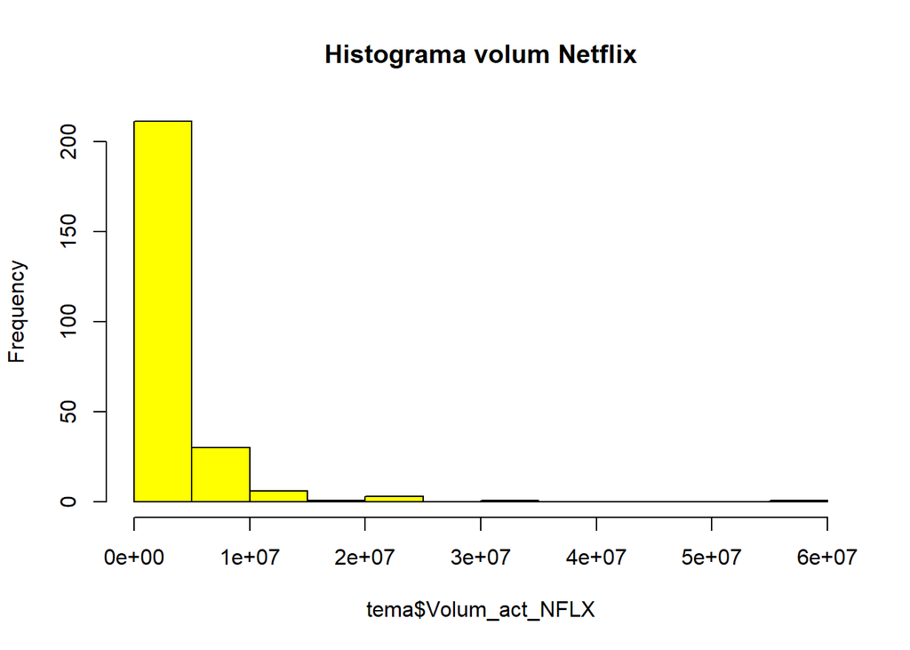

```r
hist(tema$Volum_act_NFLX, col="yellow", main="Histograma volum Netflix")
```

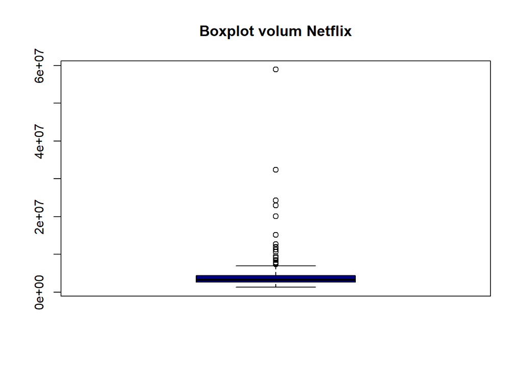

```r
boxplot(tema$Volum_act_NFLX, col="navy",main="Boxplot volum Netflix")
```

identificare outlieri

```r
outlier_volum_netflix=boxplot(tema$Volum_act_NFLX,plot=F)$out
View(as.matrix(outlier_volum_netflix))
```

Analiza volum Nasdaq

```r
summary(tema$Volum_indice.Nasdaq)
```

```
##      Min.   1st Qu.    Median      Mean   3rd Qu.      Max.
## 3.380e+09 4.151e+09 4.553e+09 4.910e+09 5.362e+09 1.017e+10
```

```r
mean(tema$Volum_indice.Nasdaq)
```

```
## [1] 4909650435
```

in medie volumul Nasdaq este egal cu 4909650435

```r
sd(tema$Volum_indice.Nasdaq)
```

```
## [1] 1109428059
```

in medie valorile se abat de la media generala cu 1109428059

```r
cv=sd(tema$Volum_indice.Nasdaq)/mean(tema$Volum_indice.Nasdaq)
cv
```

```
## [1] 0.2259688
```

cv= 0.2259688<0.30 => media este reprezentativa si seria este omogena

```r
skewness(tema$Volum_indice.Nasdaq)
```

```
## [1] 1.699124
```

coef de asimetrie= 1.699124>0 =>asimetrie pozitiva la dreapta, deci predomina valorile mici

```r
kurtosis(tema$Volum_indice.Nasdaq)
```

```
## [1] 6.732654
```

6.732654>3 => distributie leptokurtica

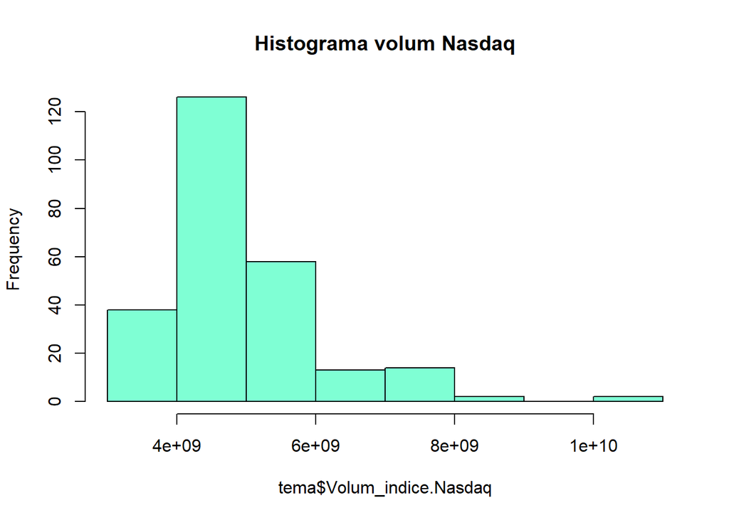

```r
hist(tema$Volum_indice.Nasdaq, col="aquamarine", main="Histograma volum Nasdaq")
```

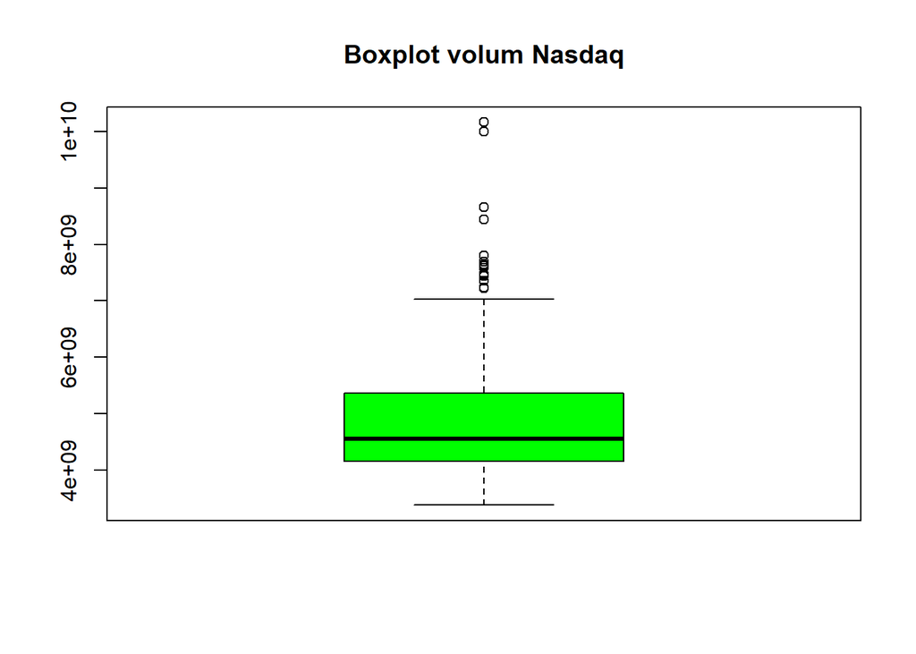

```r
boxplot(tema$Volum_indice.Nasdaq, col="green",main="Boxplot volum Nasdaq")
```

```r
outlier_volum_nasdaq=boxplot(tema$Volum_indice.Nasdaq,plot=F)$out
View(as.matrix(outlier_volum_nasdaq))
```

Analiza pret Netflix

```r
summary(tema$Pret_act_NFLX)
```

```
##    Min. 1st Qu.  Median    Mean 3rd Qu.    Max.
##   359.7   512.4   541.6   555.0   599.1   691.7
```

```r
mean(tema$Pret_act_NFLX)
```

```
## [1] 555.0135
```

```r
sd(tema$Pret_act_NFLX)
```

```
## [1] 62.0871
```

```r
cv=sd(tema$Pret_act_NFLX)/mean(tema$Pret_act_NFLX)
cv
```

```
## [1] 0.1118659
```

cv=0.111<0.30=> media reprezentativa si serie omogena

```r
skewness(tema$Pret_act_NFLX)
```

```
## [1] 0.1091461
```

coef de asimetrie=0.1091461>0=>asimetrie pozitiva la dreapta

```r
kurtosis(tema$Pret_act_NFLX)
```

```
## [1] 3.328139
```

3.3281>3=>distributie leptokurtica

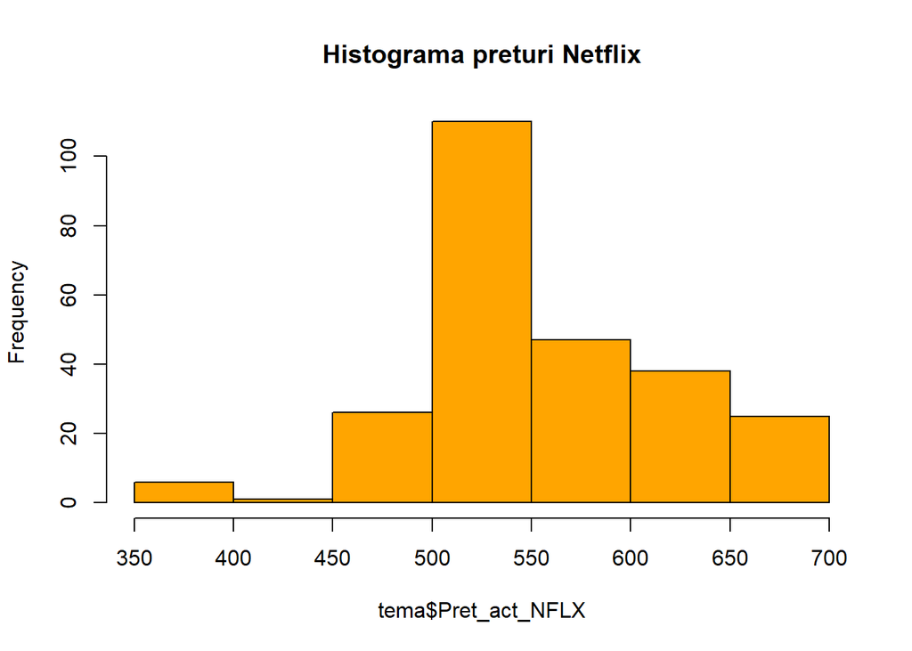

```r
hist(tema$Pret_act_NFLX,col="orange",main="Histograma preturi Netflix")
```

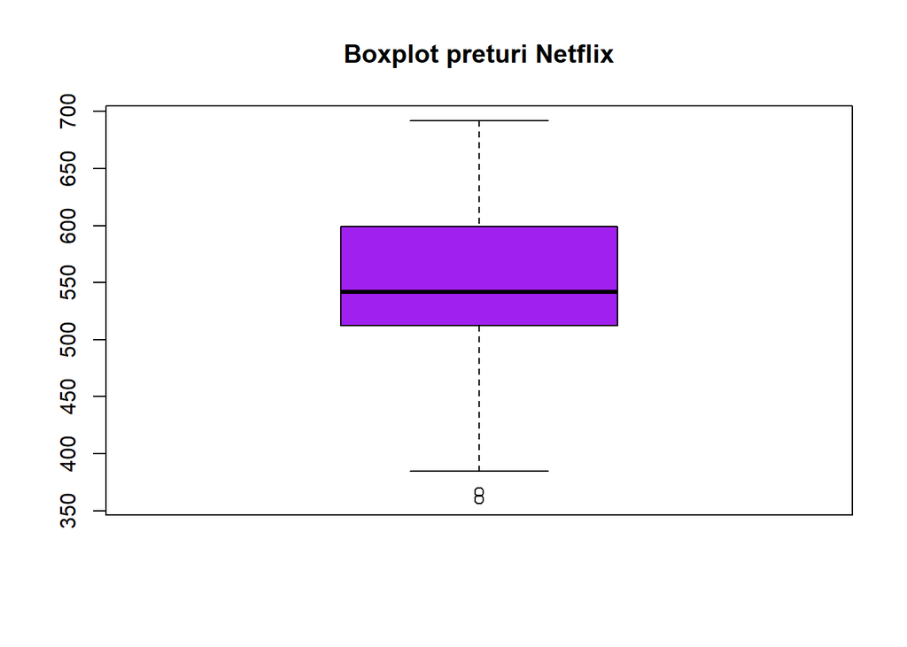

```r
boxplot(tema$Pret_act_NFLX,col="purple",main="Boxplot preturi Netflix")
```

```r
outlier_pret_netflix=boxplot(tema$Pret_act_NFLX,plot=F)$out
View(as.matrix(outlier_pret_netflix))
```

Analiza pret Nasdaq

```r
summary(tema$Pret_indice.Nasdaq)
```

```
##    Min. 1st Qu.  Median    Mean 3rd Qu.    Max.
##   12609   13786   14528   14473   15122   16057
```

```r
mean(tema$Pret_indice.Nasdaq)
```

```
## [1] 14473.28
```

```r
sd(tema$Pret_indice.Nasdaq)
```

```
## [1] 832.357
```

```r
cv=sd(tema$Pret_indice.Nasdaq)/mean(tema$Pret_indice.Nasdaq)
cv
```

```
## [1] 0.05750989
```

cv=0.057<0.3=>medie reprezentativa si serie omogena

```r
skewness(tema$Pret_indice.Nasdaq)
```

```
## [1] -0.01453619
```

-0.01<0=>asimetrie negativa la stanga predomina valorile mari

```r
kurtosis(tema$Pret_indice.Nasdaq)
```

```
## [1] 2.02854
```

2.02854<3 rezulta distributie platikurtica

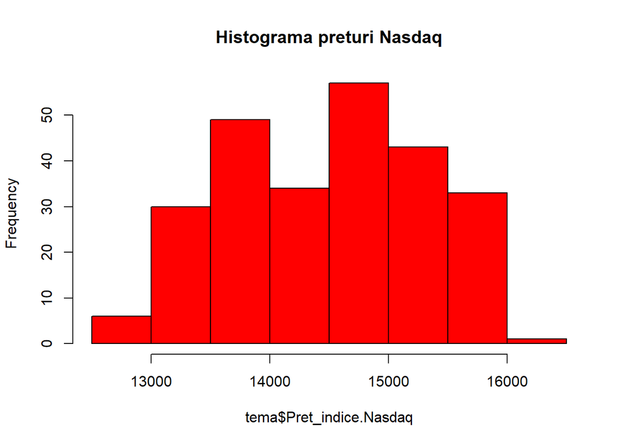

```r
hist(tema$Pret_indice.Nasdaq,col="red",main="Histograma preturi Nasdaq")
```

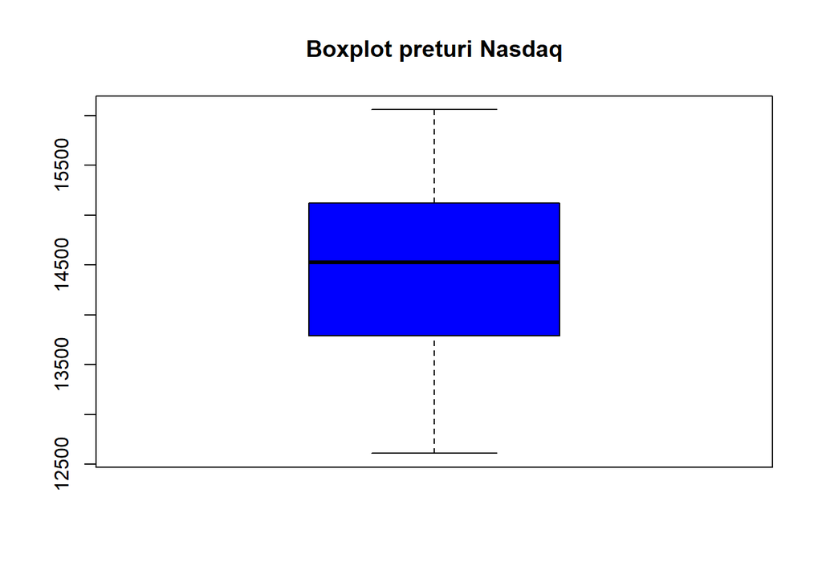

```r
boxplot(tema$Pret_indice.Nasdaq,col="blue",main="Boxplot preturi Nasdaq")
```

outlieri pret nasdaq

```r
outlier_pret_nasdaq=boxplot(tema$Pret_indice.Nasdaq,plot=F)$out
#View(as.matrix(outlier_pret_nasdaq))
```

Analiza ratei de rentabilitate Netflix

```r
summary(tema$r_netflix)
```

```
##       Min.    1st Qu.     Median       Mean    3rd Qu.       Max.
## -0.2179046 -0.0093083  0.0008817 -0.0006334  0.0101817  0.1113020
```

```r
mean(tema$r_netflix)
```

```
## [1] -0.0006333868
```

```r
sd(tema$r_netflix)
```

```
## [1] 0.02332478
```

```r
cv_rent_netflix=sd(tema$r_netflix)/mean(tema$r_netflix)
cv_rent_netflix
```

```
## [1] -36.82549
```

```r
skewness(tema$r_netflix)
```

```
## [1] -2.812534
```

-2.812<0=>asimetrie la stanga predomina valori mari

```r
kurtosis(tema$r_netflix)
```

```
## [1] 33.8453
```

33.8453>3 =>distributie leptokurtica

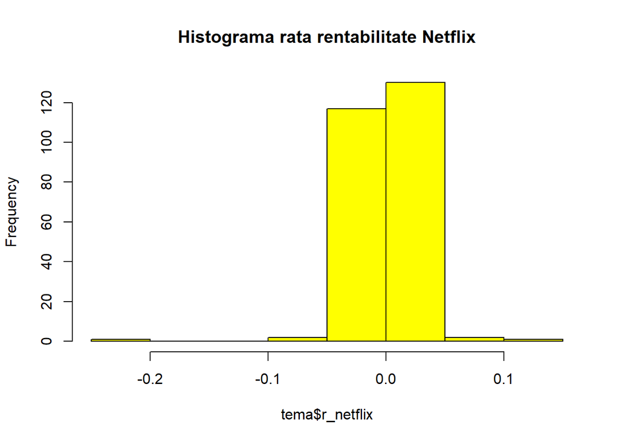

```r
hist(tema$r_netflix,col="yellow",main="Histograma rata rentabilitate Netflix")
```

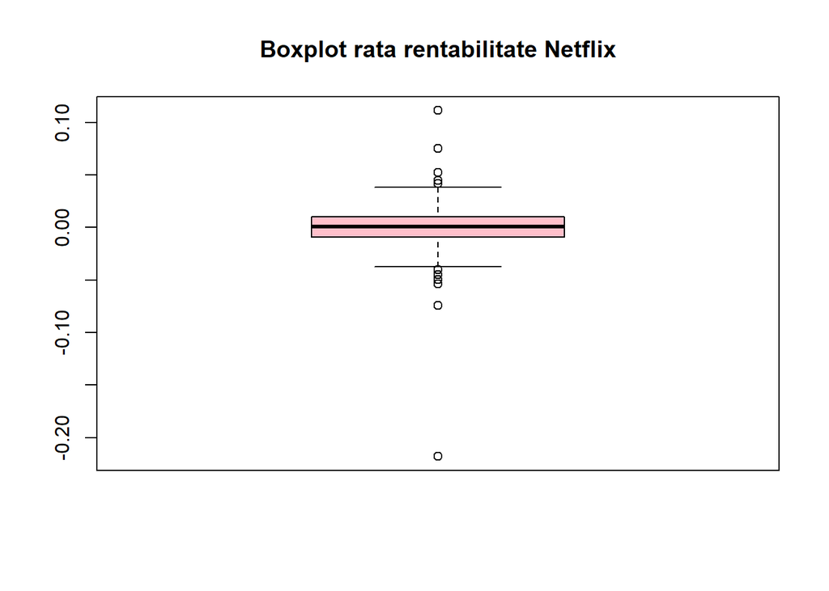

```r
boxplot(tema$r_netflix,col="pink",main="Boxplot rata rentabilitate Netflix")
```

outlieri

```r
outlier_r_netflix=boxplot(tema$r_netflix,plot=F)$out
View(as.matrix(outlier_r_netflix))
```

Analiza ratei de rentabilitate Nasdaq

```r
mean(tema$r_nasdaq)
```

```
## [1] 0.0003099121
```

```r
sd(tema$r_nasdaq)
```

```
## [1] 0.01189421
```

```r
cv_rent_nasdaq=sd(tema$r_nasdaq)/mean(tema$r_nasdaq)
cv_rent_nasdaq
```

```
## [1] 38.3793
```

```r
skewness(tema$r_nasdaq)
```

```
## [1] -0.2659376
```

```r
kurtosis(tema$r_nasdaq)
```

```
## [1] 3.842497
```

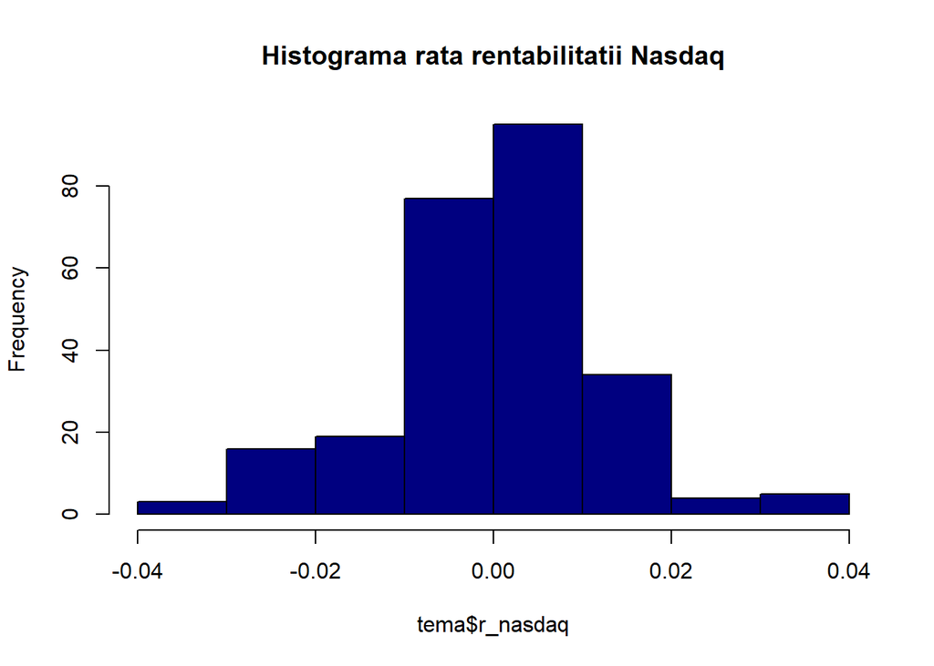

```r
hist(tema$r_nasdaq,col="navy",main="Histograma rata rentabilitatii Nasdaq")
```

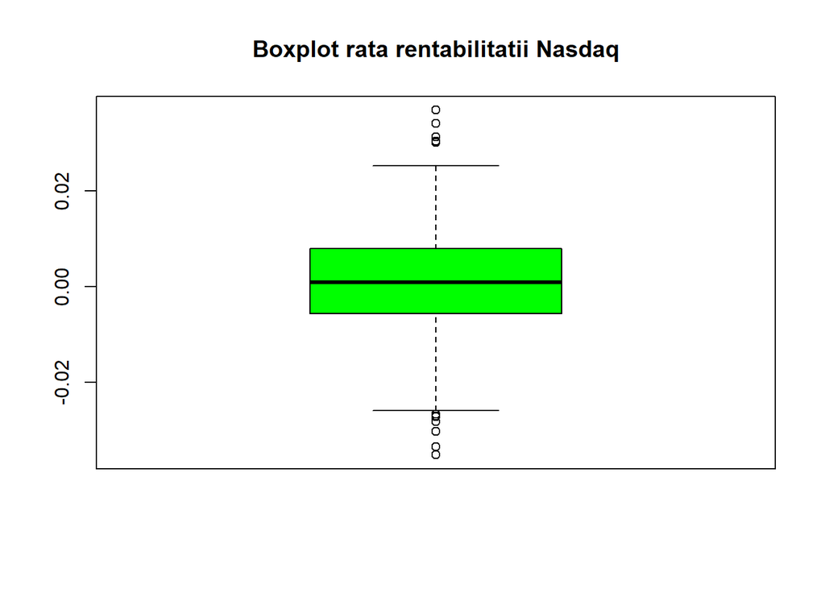

```r
boxplot(tema$r_nasdaq,col="green",main="Boxplot rata rentabilitatii Nasdaq")
```

outlieri

```r
outlier_r_nasdaq=boxplot(tema$r_nasdaq,plot=F)$out
View(as.matrix(outlier_r_nasdaq))
```

dev.off() ca sa ne apara doar un grafic

Realizarea matricei de corelatie

```r
matrice_cor=cor(tema[-1],)
View(matrice_cor)
```

Realizare grafic matrice de corelatie

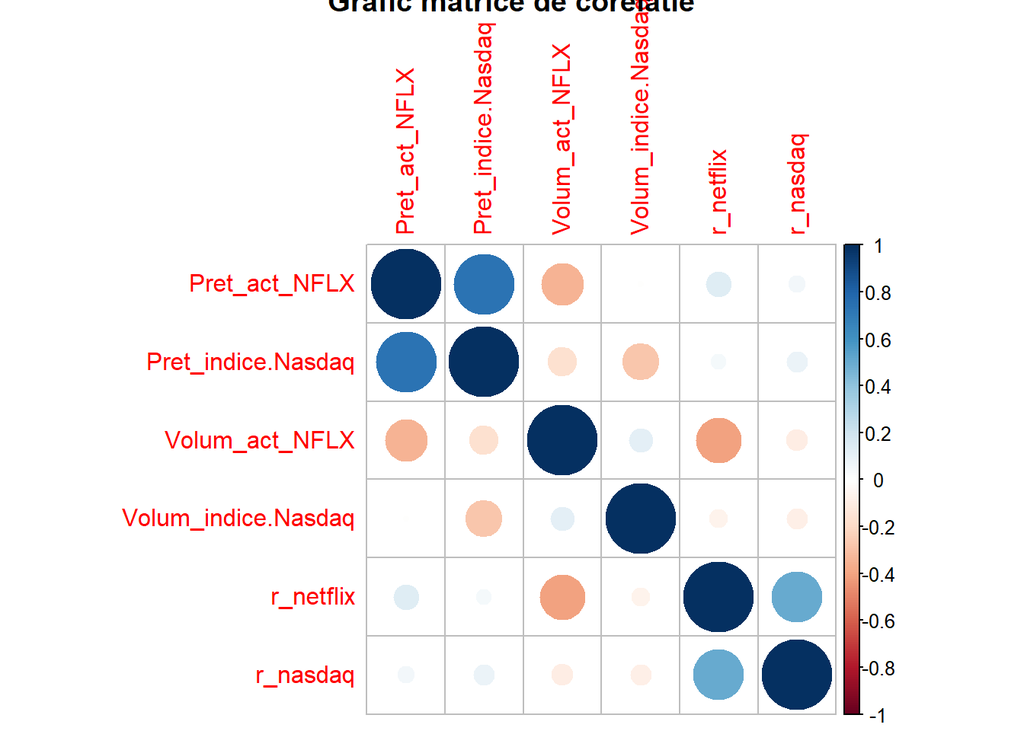

```r
corrplot(matrice_cor,method="circle",main="Grafic matrice de corelatie")
```

```r
dev.off()
```

Pas 4

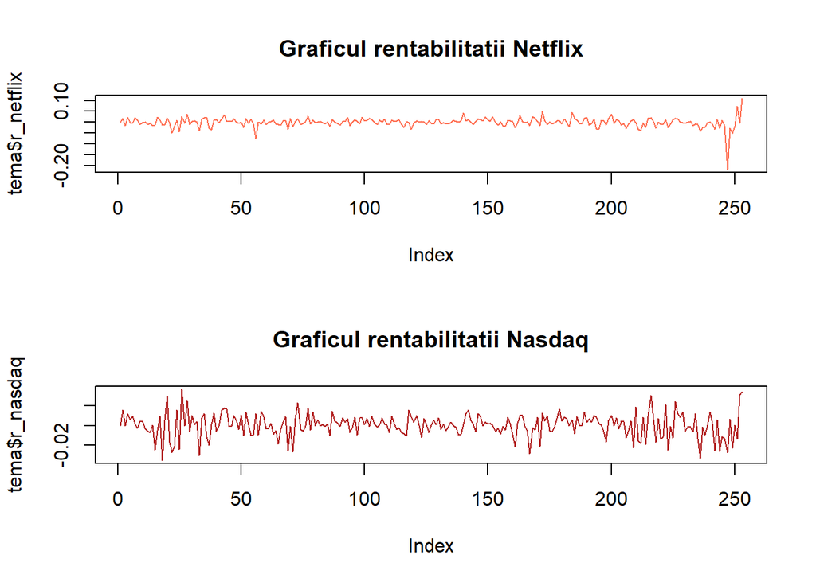

```r
View(tema)
par(mfrow=c(2,1))
plot(tema$r_netflix,col="coral1", main="Graficul rentabilitatii Netflix", type="l")
plot(tema$r_nasdaq,col="firebrick", main="Graficul rentabilitatii Nasdaq", type="l")
```

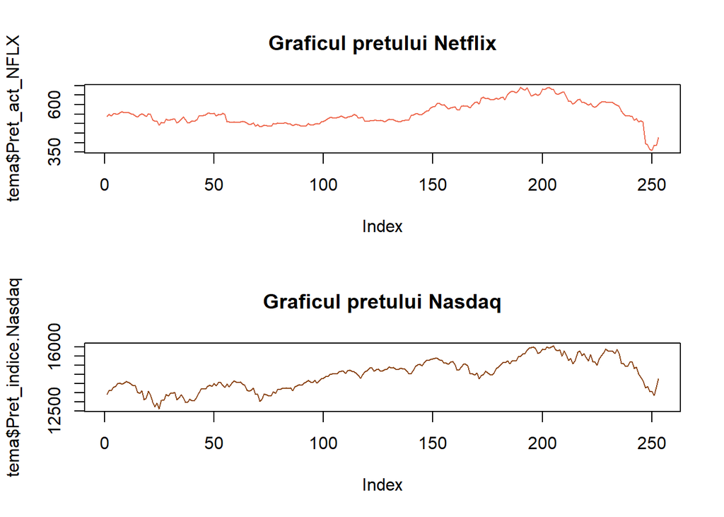

```r
plot(tema$Pret_act_NFLX,col="coral2", main="Graficul pretului Netflix", type="l")
plot(tema$Pret_indice.Nasdaq,col="chocolate4", main="Graficul pretului Nasdaq", type="l")
```

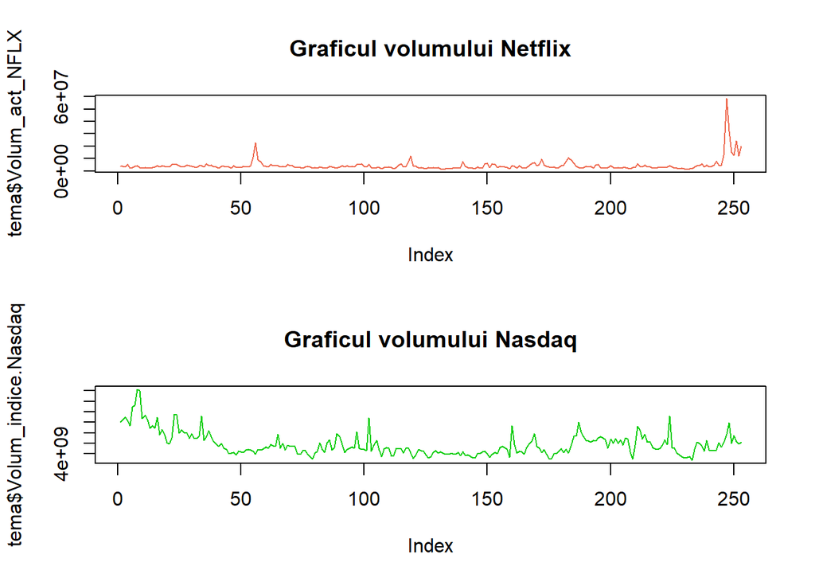

```r
plot(tema$Volum_act_NFLX,col="coral2", main="Graficul volumului Netflix", type="l")
plot(tema$Volum_indice.Nasdaq,col="green3", main="Graficul volumului Nasdaq", type="l")
```

identificare

```r
tema[which.max(tema$Pret_act_NFLX),]
```

```
##           Data Pret_act_NFLX Pret_indice.Nasdaq Volum_act_NFLX
## 203 17.11.2021        691.69           15921.57        2732800
##     Volum_indice.Nasdaq   r_netflix     r_nasdaq
## 203          5024540000 0.006240876 -0.003273475
```

```r
tema[which.max(tema$Pret_indice.Nasdaq),]
```

```
##           Data Pret_act_NFLX Pret_indice.Nasdaq Volum_act_NFLX
## 205 19.11.2021         678.8           16057.44        2613700
##     Volum_indice.Nasdaq    r_netflix    r_nasdaq
## 205          4849160000 -0.004721316 0.003984721
```

```r
tema[which.max(tema$Volum_act_NFLX),]
```

```
##           Data Pret_act_NFLX Pret_indice.Nasdaq Volum_act_NFLX
## 247 21.01.2022         397.5           13768.92       58904300
##     Volum_indice.Nasdaq  r_netflix    r_nasdaq
## 247          5845830000 -0.2179046 -0.02720779
```

```r
tema[which.max(tema$Volum_indice.Nasdaq),]
```

```
##         Data Pret_act_NFLX Pret_indice.Nasdaq Volum_act_NFLX
## 8 10.02.2021        563.59           13972.53        3991300
##   Volum_indice.Nasdaq   r_netflix     r_nasdaq
## 8         10165550000 0.008084891 -0.002510757
```

```r
tema[which.max(tema$r_netflix),]
```

```
##           Data Pret_act_NFLX Pret_indice.Nasdaq Volum_act_NFLX
## 253 31.01.2022        427.14           14239.88       20047500
##     Volum_indice.Nasdaq r_netflix   r_nasdaq
## 253          5111460000  0.111302 0.03408062
```

```r
tema[which.max(tema$r_nasdaq),]
```

```
##          Data Pret_act_NFLX Pret_indice.Nasdaq Volum_act_NFLX
## 26 09.03.2021        506.44           13073.82        3470000
##    Volum_indice.Nasdaq  r_netflix r_nasdaq
## 26          6294910000 0.02657453 0.036851
```